# Predicting heart attack occurrence in Indonesia

Final Project  
Data Science 3 with R (STAT 301-3)

Authors

Amelia Zhang

Angela Zhong

Chloe Liu

Sherry Huang

## Github Repo Link

**Tip**

[P<0.05’s Github repo](https://github.com/stat301-3-2025-spring/final-project-3-p-0-05.git)

## Introduction & Prediction Problem

The dataset for our project captures comprehensive health information from individuals in Indonesia, with the goal of predicting heart attack risk. It includes demographic details, clinical indicators, lifestyle habits, and environmental exposures—covering key variables such as hypertension, diabetes, obesity, smoking status, and air pollution levels.

The primary objective is to predict **heart attack occurrence** (binary outcome) using demographic, clinical, lifestyle, and environmental predictors. This is a **classification** problem, as our target variable `heart_attack` (1 = Yes, 0 = No) will be converted to a factor variable. Our goal is to identify key risk factors and build a predictive model to assess cardiovascular risk in Indonesian populations.

### Motivation

Given the growing prevalence of cardiovascular diseases in Indonesia, this dataset is designed to support machine learning models for early risk prediction, as well as inform public health and epidemiological research.

### Predictors

**Demographics**  
- `age`: Continuous (25-90 years)  
- `gender`: Binary (Male/Female)  
- `region`: Urban/Rural residence  
- `income_level`: Socioeconomic status (Low/Middle/High)

**Clinical Risk Factors**  
- `hypertension`, `diabetes`, `obesity`: Binary (Yes/No)  
- `cholesterol_level`: Continuous (mg/dL)  
- `waist_circumference`: Continuous (cm)  
- `family_history`: Binary family history  
- `blood_pressure_systolic`, `blood_pressure_diastolic`: Continuous (mmHg)  
- `fasting_blood_sugar`: Continuous (mg/dL)

**Lifestyle Factors**  
- `smoking_status`: Never/Past/Current  
- `alcohol_consumption`: None/Moderate/High  
- `physical_activity`: Low/Moderate/High  
- `dietary_habits`: Healthy/Unhealthy  
- `sleep_hours`: Continuous (3-9 hrs/night)

**Environmental Factors**  
- `air_pollution_exposure`: Low/Moderate/High  
- `stress_level`: Low/Moderate/High

**Medical History**  
- `EKG_results`: Normal/Abnormal  
- `previous_heart_disease`: Binary  
- `medication_usage`: Binary  
- `participated_in_free_screening`: Binary

### Target variable analysis

The target variable is the binary indicator `heart_attack`, reflecting whether an individual has experienced a heart attack.

- **Prevalence**: 63,501 out of 158,355 participants (40.1%) are labeled as positive for a heart attack.
- **Class Imbalance**: While not extremely skewed, the class distribution indicates a moderate imbalance (59.9% negative vs. 40.1% positive), which may require addressing during model training (e.g., stratified sampling).
- **Missingness**: No missing values were found in this variable.

Table 1: Heart Attack Class Breakdow

| heart_attack | n | Percent |
| --- | --- | --- |
| 0 | 94854 | 59.9 |
| 1 | 63501 | 40.1 |

Table 1 shows a slight class imbalence between groups with and without heart attack.

### Demographic Breakdown

These patterns not only validate the dataset’s quality but also offer valuable insight into risk stratification and population-specific modeling strategies.

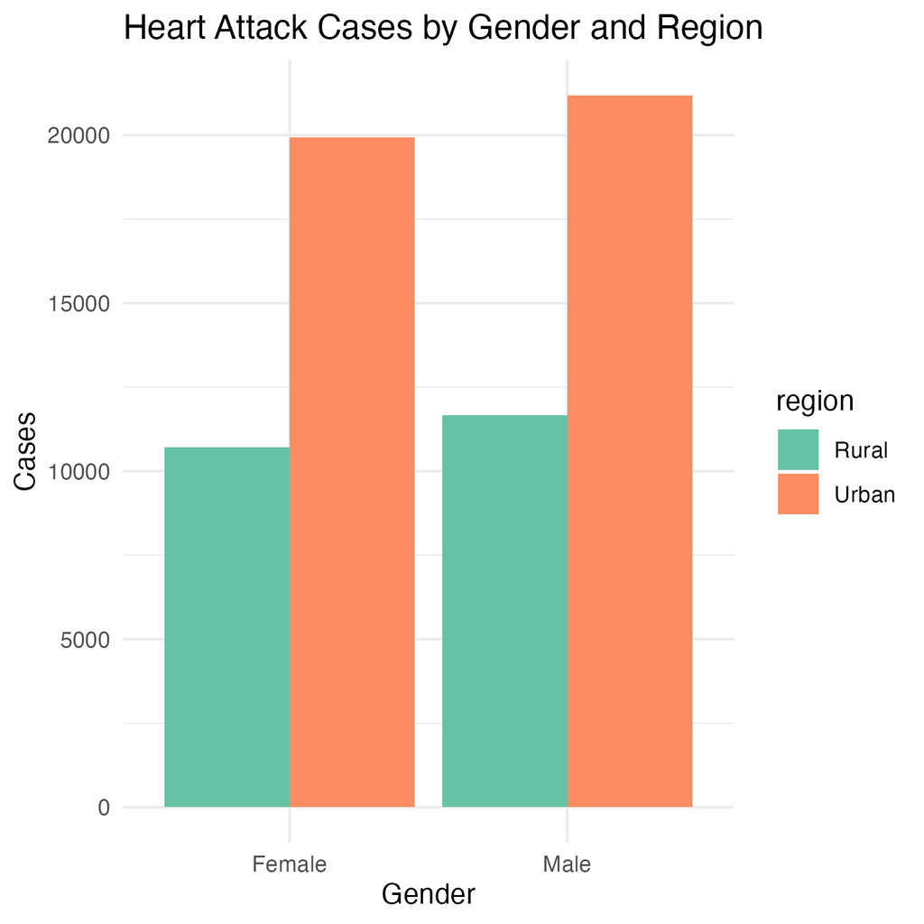

(a) Heart Attack Distribution By Gender and Region

Figure 1

[figure not shown]

(a) Heart Attack Distribution By Age

Figure 2

## Methods

### Data splitting

**Downsampling**: Because we have a huge dataset of over 158355 columns, we downsampled it to 20% of the size of the original dataset.

**Training/Testing Split**: 80% training, 20% testing. Stratified sampling across the outcome variable will ensure proportional representation of heart attack occurrence across splits.

**Resampling**: 5-fold cross-validation with 3 repeats on the training set to tune hyper-parameters and evaluate performance.

### Models

#### Null

- baseline model used to predict `heart_attack`, used as a baseline of comparison for other methods
- no tuning involved

#### Logistic Regression

- A linear model using the glm engine.
- No tuning was performed.

#### Elastic Net

- A regularized regression model using the `glm` engine.
- Parameters: `penalty` with a range of `[-4, 0]` and `mixture` with a range of `[0, 1]` with `5` levels.

#### Random Forest

- A tree-based model using the ranger engine
- trees explored over `[100, 1000]` with 4 levels.
- mtry explored over `[1, 10]` with 4 levels.
- min_n explored over `[2, 10]` with 4 levels.
- This model builds multiple decision trees and averages their predictions to reduce over-fitting.

#### K-Nearest Neighbors

- A K-nearest neighbors model using the kknn engine.
- `neighbors` was explored over a range of `[1,40]` with 5 levels.

#### Support Vector Machine (RBF Kernel)

- A support vector machine model using the `kernlab` engine with a radial basis function kernel.
- Cost explored over `[0.001,100]` on a log scale (log10-transformed from −3 to 2) with 4 levels.
- RBF Sigma explored over `[0.001,1]` on a log scale (log10-transformed from −3 to 0) with 4 levels.

#### Neural Network (Multilayer Perceptron)

- A neural network model using the `nnet` engine.
- Hidden units explored over `[1,10]` with 4 levels.
- Penalty (weight decay) explored over `[0.0001,1]` on a log scale (log10-transformed from −4 to 0) with 4 levels.

#### Model Stacking Ensemble

- An ensemble model combining multiple base learners using the stacks package.
- Candidate models included:
  - Boosted Trees (bt_tuned_1)
  - Multivariate Adaptive Regression Splines (MARS) (mars_tuned)
  - Elastic Net Logistic Regression (en_tuned)
- Blending penalty explored over`10^-6 to 10^1` (20 logarithmically spaced values) to optimize model combination weights.

#### Multivariate Adaptive Regression Splines (MARS)

- A MARS model using the `earth` engine.
- Number of terms (num_terms) explored over `[5,25]` with 4 levels.
- Interaction degree (prod_degree) explored over values `{1,2}`, controlling whether interactions between predictors are included.

### Feature Engineering

In the model selection stage, we created a two basic recipes.

#### Simple recipe

The recipe_basic sets up a clean and efficient pre-processing pipeline for modeling `heart_attack` using the `heart_train` data set. It starts by dealing with categorical variables, adding a “new” level for any categories that might show up in testing but weren’t in training, combining rare levels (those that appear in less than 1% of the data) into an “other” group, and assigning “unknown” to missing values. Then it one-hot encodes all the categorical variables so they can work with most models. After that, it removes any predictors that have zero variance and drops highly correlated numeric variables (those with correlation above 0.9) to avoid redundancy. Finally, it normalizes all numeric variables so they’re on the same scale. Overall, this recipe is doing a lot of cleanup, making sure the data is tidy, consistent, and ready to go into any model.

#### Tree recipe

In this recipe, we updated the dummy encoding method. `recipe_basic_tree` uses true one-hot encoding by keeping all levels of categorical variables.

### Metrics used

We used `accuracy` as our metrics because this is a classification problem. It measures how often a classification model correctly predicts the outcome.

## Model Building & Selection Results

### Metrics

The metric that is used to compare models and determine the best-performing model for our classification problem is **accuracy**. It represents the percentage of time that the model correctly predicts the target variable, which is whether there is a heart attack occurrence. A higher accuracy means that the model has a better predictive performance.

### Table of Best Performing Model

Table 2: best-model-result

| Model | Accuracy | Accuracy_Std_Error |
| --- | --- | --- |
| Ensemble | 0.739 | 0.006 |
| MARS | 0.733 | 0.001 |
| MARS (Refined) | 0.733 | 0.002 |
| Boosted Tree | 0.733 | 0.001 |
| Random Forest | 0.729 | 0.001 |
| Elastic Net | 0.727 | 0.001 |
| Elastic Net (Refined) | 0.727 | 0.001 |
| NN | 0.727 | 0.001 |
| Logistic Regression | 0.726 | 0.001 |
| SVM_rbf | 0.726 | 0.001 |
| K-Nearest Neighbors | 0.672 | 0.001 |
| Null | 0.599 | 0.000 |

As shown by the table, the top performing models are **Ensemble model, MARS, Boosted Tree, Random Forest and Elastic Net model**. The highest accuracy is from the Ensemble model with an accuracy of 0.739 with a standard error of 0.00552. This means that the ensemble model correctly predicts whether a person has heart disease **73.9%** of the time. A small standard error means that the accuracy is highly stable across different training folds. The second best performing model, MARS, has a slightly lower accuracy of 0.733 and an even smaller accuracy standard error. We decided to not tune the Random Forest model because it has a lower performance than the Boosted Tree model and they are both tree-based models. Therefore, we eventually decided to tune the** MARS, Boosted Tree and Elastic Net** model to reduce redundancy and we will also see the accuracy for the resulting ensemble model after the refinement process. We further created the autoplot of these models to see the direction of refinements.

## Model Refinement

### Advanced Recipe

We decided to also create an advanced recipe that creates two new ratio features, cholesterol balance and blood pressure dynamics. It adds 6 custom interaction terms capturing non-linear relationships, helping the model capture complex effects that wouldn’t be captured by main effects alone. We also added YeoJohnson to handle skewed numeric variables (including zero and negative values).

The recipe_advanced_tree is an enhanced preprocessing pipeline tailored specifically for tree-based models with one hot encoding.

### Tuning

#### MARS

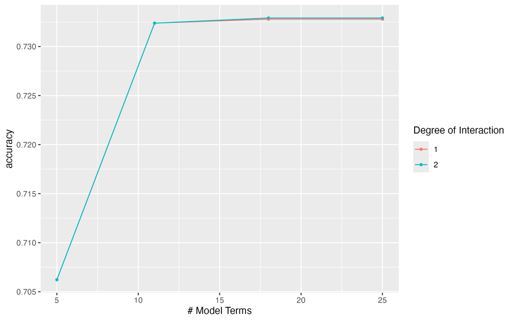

(a) Tuning Parameters for MARS Model with basic recipe

Figure 3

The graph Figure 3 shows that as the number of model terms increases, accuracy seems to also improve slightly. In the future, we aim to explore a higher num_terms to c(10,40), and we will keep the prod_degree the same, c(1,2), because they don’t seem to result in a big difference in accuracy.

#### Elastic Net

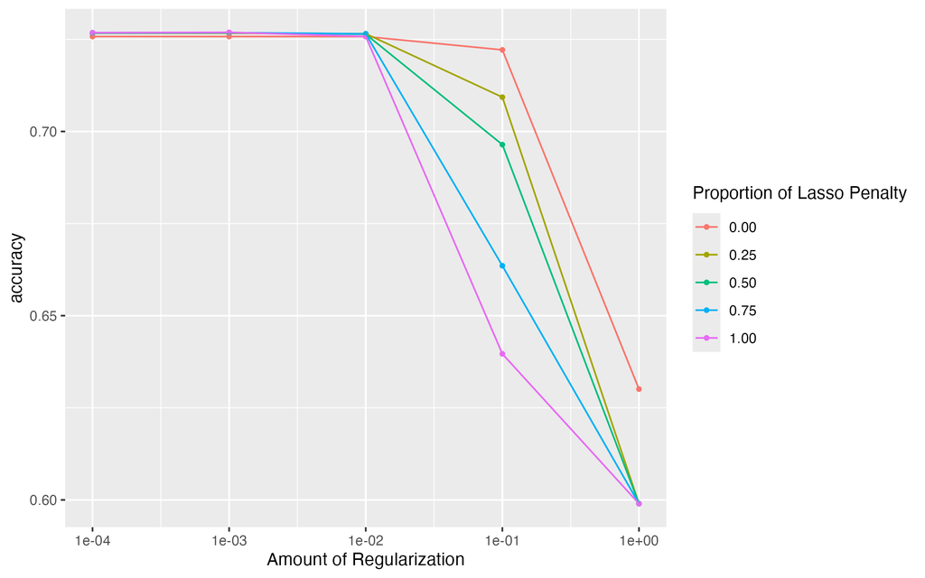

(a) Tuning Parameters for Elastic Net Model with basic recipe

Figure 4

The graphs Figure 4 show that penalties >1e-2 hurt performance across all mixture values. We will explore a narrowed penalty range from c(-5, -1) which is the range with the highest accuracy.

#### Boosted Tree

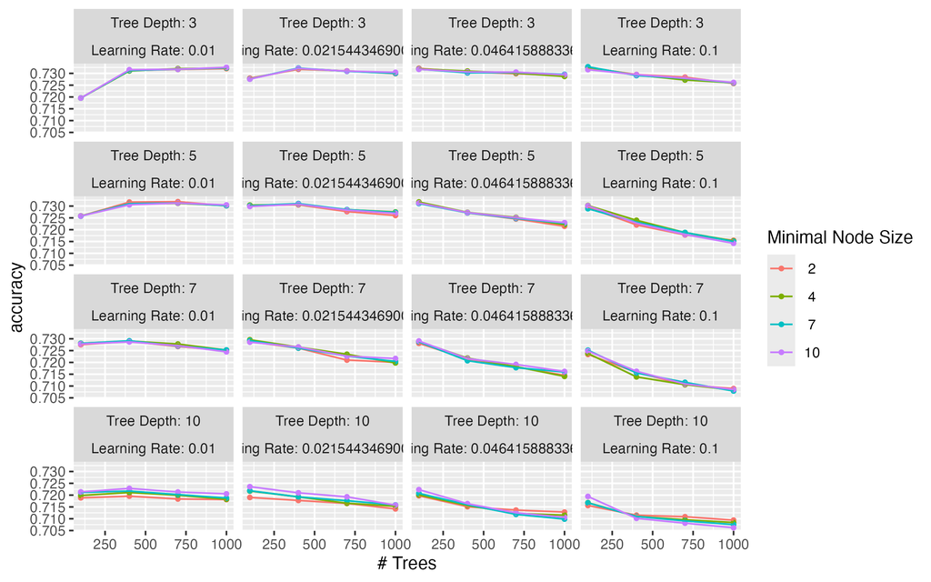

(a) Tuning Parameters for Boosted Tree Model with basic tree recipe

Figure 5

## Final Model Analysis

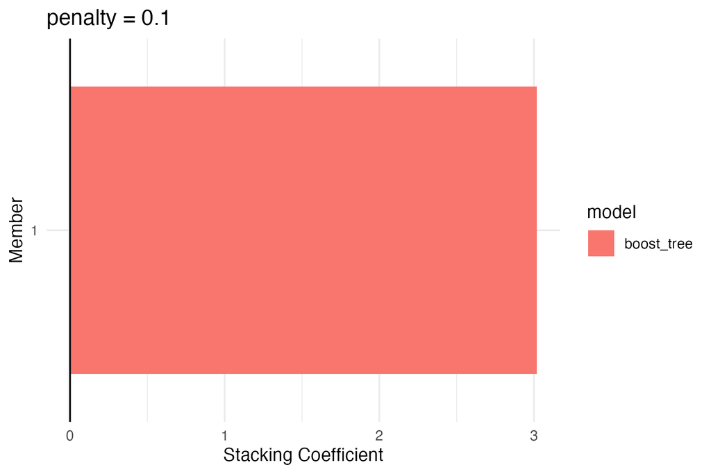

Figure 6: ensemble-model-results

Figure 7 shows the performance of the heart attack prediction model. The model correctly predicted 3,353 non-heart attack cases and 1,355 heart attack cases, but misclassified 1,185 non-heart attack cases as heart attacks and 441 heart attack cases as non-heart attacks. While the model performs reasonably well overall, the number of false positives (1,185) is relatively high, indicating a tendency to overpredict heart attack risk.

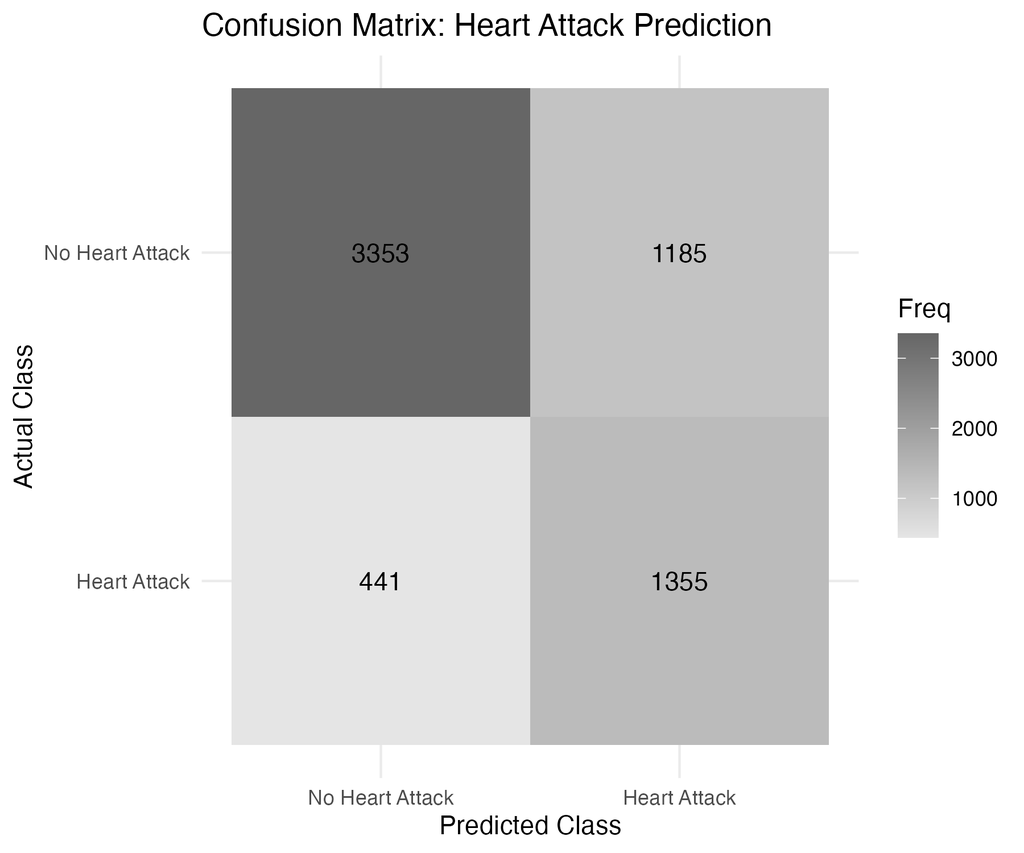

Figure 7: heatmap-of-results

Table 3: final-model-results

| .metric | .estimator | .estimate |
| --- | --- | --- |
| accuracy | binary | 0.743 |
| kap | binary | 0.438 |

Table 4: ensemble-model-comparison

| Model | Accuracy | Accuracy_Std_Error |
| --- | --- | --- |
| Ensemble | 0.743 | 0.005 |
| MARS | 0.733 | 0.002 |
| Boosted Tree | 0.732 | 0.001 |
| Elastic Net | 0.727 | 0.001 |

Table 3 shows that our final stacke-final-model-resud ensemble model was evaluated on the test set. It achieved an accuracy of 0.743. This means the model correctly predicted whether a heart attack occurred in approximately 74.3% of cases. This shows the predictive power of the model, and it outperforms individual base models including boosted tree, elastic net and mars. Our model also achieves a Cohan Kappa score of 0,438, which indicates moderate agreement beyond chance, suggesting the model is reasonably reliable in distinguishing positive and negative outcomes.

Table 4 shows how our final ensemble model performed relative to other top models.

## Notes

Generative AI such as ChatGPT and DeepSeek was used in the creation of these models, such as editing written paragraphs, debugging, and adjusting existing scripts.